# B站python数据分析

字符串的分割

```python
s = "hello, world"
s.split()
```

```
['hello,', 'world']
```

```python
s = 'hello, world'
s.split(',')
```

```
['hello', ' world']
```

```python
4/5
```

```
0.8
```

```python
4//5
```

```
0
```

```python
4%5
```

```
4
```

```python
a = (list('1234'))
a
```

```
['1', '2', '3', '4']
```

```python
a = int(a[0])
a
```

```
1
```

```python
[int(x) for x in range('123455')]
```

```
---------------------------------------------------------------------------
TypeError                                 Traceback (most recent call last)
<ipython-input-21-b29acab5aa7e> in <module>
----> 1 [int(x) for x in range('123455')]

TypeError: 'str' object cannot be interpreted as an integer
```

```python
import matplotlib.pyplot as plt
import numpy as np
```

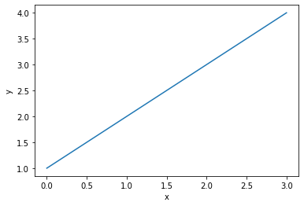

```python
plt.plot([1,2,3,4])
plt.ylabel('y')
plt.xlabel('x')
plt.show()
```

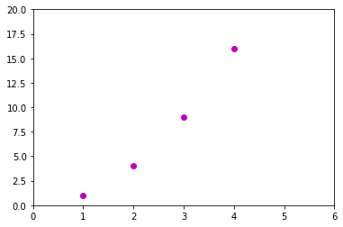

```python
x = [1,2,3,4]
y = [1,4,9,16]
plt.plot(x, y, 'mo')
plt.axis([0,6,0,20])
plt.show()
```

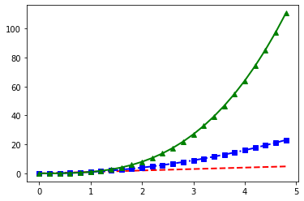

```python
t = np.arange(0., 5., 0.2)
plt.plot(t, t, 'r--',
        t, t**2, 'bs-.',
        t, t**3, '-g^',linewidth=2,)
plt.show()
```

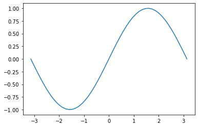

```python
x = np.linspace(-np.pi, np.pi)
y=np.sin(x)
plt.plot(x,y)
plt.show()
```

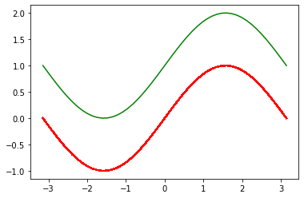

```python
line1, line2 = plt.plot(x,y,'r-',x,y+1,'g-')
line1.set_antialiased(False)
plt.show()
```

[output not shown]

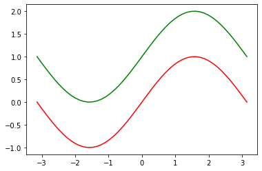

```python
line = plt.plot(x,y,'r-',x,y+1,'g-')
line.set_antialiased(False)
plt.show()
```

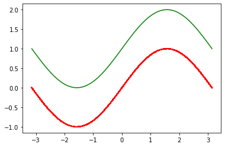

```python
line = plt.plot(x,y,'r-',x,y+1,'g-')
line[0].set_antialiased(False)
plt.show()
```

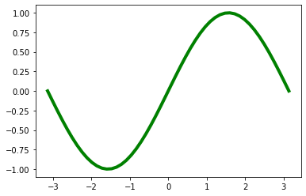

```python
line = plt.plot(x,y)
plt.setp(line,color='g', linewidth=4)
plt.show()
```

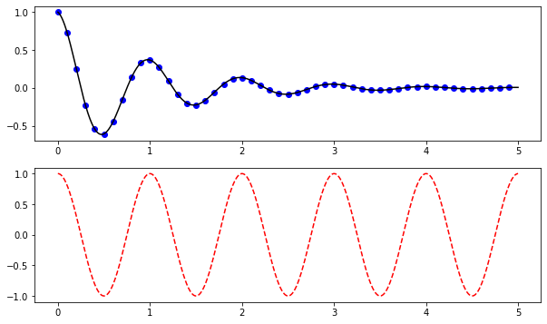

```python
def f(t):
    return np.exp(-t)*np.cos(2*np.pi*t)

t1 = np.arange(0.0, 5.0, 0.1)
t2 = np.arange(0.0, 5.0, 0.002)

plt.figure(figsize=(10,6))
plt.subplot(211)
plt.plot(t1, f(t1), 'bo', t2, f(t2), 'k')

plt.subplot(212)
plt.plot(t2, np.cos(2*np.pi*t2),'r--')\
# plt.show()
```

```python
import warnings
warnings.filterwarnings('ignore')
```

```python
import pandas as pd
import numpy as np
import matplotlib.pyplot as plt
```

```python
plt.rcParams['font.sans-serif']=['SimHei']
plt.rcParams['axes.unicode_minus']=False
```

```python
df = pd.read_excel('movie_data3.xlsx')
```

```python
df[:5]
```

|  | Unnamed: 0 | 名字 | 投票人数 | 类型 | 产地 | 上映时间 | 时长 | 年代 | 评分 | 首映地点 |
| --- | --- | --- | --- | --- | --- | --- | --- | --- | --- | --- |
| 0 | 0 | 肖申克的救赎 | 692795.0 | 剧情/犯罪 | 美国 | 1994-09-10 00:00:00 | 142 | 1994 | 9.6 | 多伦多电影节 |
| 1 | 1 | 控方证人 | 42995.0 | 剧情/悬疑/犯罪 | 美国 | 1957-12-17 00:00:00 | 116 | 1957 | 9.5 | 美国 |
| 2 | 2 | 美丽人生 | 327855.0 | 剧情/喜剧/爱情 | 意大利 | 1997-12-20 00:00:00 | 116 | 1997 | 9.5 | 意大利 |
| 3 | 3 | 阿甘正传 | 580897.0 | 剧情/爱情 | 美国 | 1994-06-23 00:00:00 | 142 | 1994 | 9.4 | 洛杉矶首映 |
| 4 | 4 | 霸王别姬 | 478523.0 | 剧情/爱情/同性 | 中国大陆 | 1993-01-01 00:00:00 | 171 | 1993 | 9.4 | 香港 |

```python
df.values['评分']
```

```
---------------------------------------------------------------------------
IndexError                                Traceback (most recent call last)
<ipython-input-8-79aa44c1fa8e> in <module>
----> 1 df.values['评分']

IndexError: only integers, slices (`:`), ellipsis (`...`), numpy.newaxis (`None`) and integer or boolean arrays are valid indices
```

```python
df = np.array(df)
```

```python
df[:,3]
```

[output not shown]

## Numpy

```python
a = [1, 2, 3, 4,]
[x+1 for x in a]
```

```
[2, 3, 4, 5]
```

```python
b = [2, 3, 4, 5]
a + b
```

```
[1, 2, 3, 4, 2, 3, 4, 5]
```

```python
[x+y for (x, y) in zip(a, b)]
```

```
[3, 5, 7, 9]
```

```python
a = np.array([1, 2, 3, 4])
a
```

```
array([1, 2, 3, 4])
```

```python
a + 1
```

```
array([2, 3, 4, 5])
```

```python
a * 2
```

```
array([2, 4, 6, 8])
```

```python
a * 2b
```

```
  File "<ipython-input-17-4f52a9fe9445>", line 1
    a * 2b
         ^
SyntaxError: invalid syntax
```

```python
b = np.array([2, 3, 4, 5])
a + b
```

```
array([3, 5, 7, 9])
```

```python
l = [0, 1, 2, 3]
a = np.array(l)
a
```

```
array([0, 1, 2, 3])
```

```python
np.zeros(5)
```

```
array([0., 0., 0., 0., 0.])
```

```python
np.ones(5,dtype='int')
```

```
array([1, 1, 1, 1, 1])
```

一般都将Numpy命名为np，pandas命名为pd.

导入Numpy包，导入方法：

```python
import numpy as np
```

# 1.Numpy的数组对象及其索引

## 数组上的数学操作

两个列表相加，列表生成式方法：

```python
a = [1, 2, 3, 4]
b = [5, 6 ,7, 8]
[x+y for (x,y) in zip(a, b)]
```

```
[6, 8, 10, 12]
```

## 这样的操作比较麻烦，若数据量特别大的时候会非常耗时间

## 如果使用Numpy，可以简单化

```python
a = np.array([1, 2, 3, 4])
a
```

```
array([1, 2, 3, 4])
```

```python
a+1
```

```
array([2, 3, 4, 5])
```

```python
b = np.array([5, 6, 7, 8])
a+b
```

```
array([ 6,  8, 10, 12])
```

## 产生数组

### 从列表产生数组：

```python
l = [0,1,2,3]
a = np.array(l)
a
```

```
array([0, 1, 2, 3])
```

### 从列表传入：

```python
a = np.array([1,2,3,4])
a
```

```
array([1, 2, 3, 4])
```

### 生成全0数组：

```python
np.zeros(5)
```

```
array([0., 0., 0., 0., 0.])
```

### 生成全1数组：

```python
np.ones(5)
```

```
array([1., 1., 1., 1., 1.])
```

```python
#生成不同的类型
np.ones(5, dtype='int')
```

```
array([1, 1, 1, 1, 1])
```

```python
np.ones(5, dtype='bool')
```

```
array([ True,  True,  True,  True,  True])
```

### 可以使用fill方法将数组设为指定值：

```python
a = np.array([1,2,3,4])
a
```

```
array([1, 2, 3, 4])
```

```python
a.fill(5)
a
```

```
array([5, 5, 5, 5])
```

### 与列表不同，数组中要求所有元素dtype是一样的，如果传入参数的类型与数组类型不一样，需要按照已有的类型进行转换。

```python
a.fill(2.5)#会自动变成2
a
```

```
array([2, 2, 2, 2])
```

```python
a = a.astype('float') # 对类型进行强制更改
a.fill(2.5)
a
```

```
array([2.5, 2.5, 2.5, 2.5])
```

### 特定方法生成特殊的数组

### 生成整数序列：

```python
a = np.arange(1,10)
a
```

```
array([1, 2, 3, 4, 5, 6, 7, 8, 9])
```

```python
a = np.arange(1,11,2)
a
```

```
array([1, 3, 5, 7, 9])
```

### 生成等差数列：

```python
a = np.linspace(1, 12, 6)  #注：此处的12是包含在内的；解释：从1-12成6个等差数列的数
a
```

```
array([ 1. ,  3.2,  5.4,  7.6,  9.8, 12. ])
```

### 生成随机数：

#### rand随机数

```python
np.random.rand(10) #生成10个随机数
```

```
array([0.05733067, 0.62150718, 0.16562347, 0.43714388, 0.90932042,
       0.77512125, 0.28140809, 0.62224885, 0.6947905 , 0.11543539])
```

#### randn 标准正太分布的随机数

```python
np.random.randn(10) #生成10个标准正太分布的随机数
```

```
array([ 0.85946861, -1.08383323,  1.23185124, -1.54618361, -0.9610136 ,
        1.73088356, -0.0407034 , -2.2030209 ,  0.19080319, -1.52987622])
```

#### randint 随机整数

```python
np.random.randint(1,10,5) #生成5个1-10的随机整数数
```

```
array([4, 7, 7, 6, 6])
```

# 数组属性

### 查看类型：

```python
a
```

```
array([ 1. ,  3.2,  5.4,  7.6,  9.8, 12. ])
```

```python
type(a)
```

```
numpy.ndarray
```

### 查看数组中的数据类型：

```python
a.dtype
```

```
dtype('float64')
```

### 查看形状，会返回一个元祖，每个元素代表这一维的元素数目：

```python
a.shape
```

```
(6,)
```

### 查看数组里面元素的数目：

```python
a.size
```

```
6
```

### 查看数组维度：

```python
a.ndim
```

```
1
```

# 索引与切片

### 和列表相似，数组也支持索引和切片操作

### 索引第一个元素：

```python
a = np.array([1,2,3,4])
a[0]
```

```
1
```

### 修改第一个元素的值：

```python
a[0] =10
a
```

```
array([10,  2,  3,  4])
```

### 切片，支持负索引：

```python
a = np.array([11,12,13,14,15])
a[1:-2]
```

```
array([12, 13])
```

```python
a[-4:3]
```

```
array([12, 13])
```

### 省略参数：

```python
a[-2:]
```

```
array([14, 15])
```

```python
a[::2]
```

```
array([11, 13, 15])
```

```python
ob = np.array([12345,54127,65481,79632,556231])
ob
```

```
array([ 12345,  54127,  65481,  79632, 556231])
```

```python
ob2 = ob[1:] - ob[:-1]
ob2
```

```
array([ 41782,  11354,  14151, 476599])
```

# 多维数组及其属性

## array 还可以用来生成多维数组

```python
a = np.array([[0,1,2,3],[4,5,6,7]])
a
```

```
array([[0, 1, 2, 3],
       [4, 5, 6, 7]])
```

### 事实上我们传入的是一个以列表为元素的列表，最终得到一个二维数组

### 查看形状

```python
a.shape
```

```
(2, 4)
```

### 查看总得元素个数

```python
a.size
```

```
8
```

### 查看维数

```python
a.ndim
```

```
2
```

# 多维数组索引

### 对于二维数组，可以传入两个数字来索引

```python
a
```

```
array([[0, 1, 2, 3],
       [4, 5, 6, 7]])
```

```python
a[1,3]
```

```
7
```

```python
a[1,3]=-1
a
```

```
array([[ 0,  1,  2,  3],
       [ 4,  5,  6, -1]])
```

### 单个索引来索引一整行内容

```python
a[1]
```

```
array([ 4,  5,  6, -1])
```

### 索引列

```python
a[:,1]
```

```
array([1, 5])
```

# 多维数组切片

```python
a = np.array([[0,1,2,3,4,5],[10,11,12,13,14,15],[20,21,22,23,24,25],[30,31,32,33,34,35],[40,41,42,43,44,45],[50,51,52,53,54,55]])
a
```

```
array([[ 0,  1,  2,  3,  4,  5],
       [10, 11, 12, 13, 14, 15],
       [20, 21, 22, 23, 24, 25],
       [30, 31, 32, 33, 34, 35],
       [40, 41, 42, 43, 44, 45],
       [50, 51, 52, 53, 54, 55]])
```

### 第一行的第四和第五个元素

```python
a[0,3:5]
```

```
array([3, 4])
```

### 最后两行的最后两列

```python
a[4:,4:]
```

```
array([[44, 45],
       [54, 55]])
```

### 得到第三列

```python
a[:,2]
```

```
array([ 2, 12, 22, 32, 42, 52])
```

### 每一维都支持切片的规则，包括负索引，省略：

```
       [lower : upper : step]
```

### 取出3,5行的奇数列：

```python
a[2::2, ::2]
```

```
array([[20, 22, 24],
       [40, 42, 44]])
```

# 切片是引用

### 切片在内存中使用的是引用机制

```python
a = np.array([0,1,2,3,4])
b = a[2:4]
b
```

```
array([2, 3])
```

```python
b[0]=10
a
```

```
array([ 0,  1, 10,  3,  4])
```

### 引用机制意味着,Python并没有为b分配新的空间来存储他的值，而是让b指向了a所分配的内存空间，因此，改变b会改变a的值：

### 而这种现象在列表中并不会出现

```python
a = [1,2,3,4,5]
b = a[2:4]
b[0]=10
print(a)
```

```
[1, 2, 3, 4, 5]
```

### 这样做的好处在于，对于很大的数组，不用大量复制多余的值，节约了空间；

### 缺点在于，可能改变一个值改变另一个值得情况

### 一个解决方法是使用copy()方法产生一个复制，这个复制会申请新的内存

```python
a = np.array([0,1,2,3,4])
b = a[2:4].copy()
b[0]=10
a
```

```
array([0, 1, 2, 3, 4])
```

# 花式索引

**切片只能支持连续或者间隔的切片才做，要想实现任意位置的操作，需要使用花式索引，fancy slicing**

## 一维花式索引

**与range函数类似，可以使用arange函数来产生等差数组**

```python
a = np.arange(0,100,10)
a
```

```
array([ 0, 10, 20, 30, 40, 50, 60, 70, 80, 90])
```

### 花式索引需要指定索引位置

```python
index = [1,2,-3]
y = a[index]
y
```

```
array([10, 20, 70])
```

### 还可以使用布尔数组来花式索引：

```python
mask = np.array([0,2,2,0,0,1,0,0,1,0], dtype = bool)
mask
```

```
array([False,  True,  True, False, False,  True, False, False,  True,
       False])
```

### mask必须是布尔数组，长度必须和数组长度相等

```python
a[mask]
```

```
array([10, 20, 50, 80])
```

## 二维花式索引

```python
a = np.array([[0,1,2,3,4,5],[10,11,12,13,14,15],[20,21,22,23,24,25],[30,31,32,33,34,35],[40,41,42,43,44,45],[50,51,52,53,54,55]])
a
```

```
array([[ 0,  1,  2,  3,  4,  5],
       [10, 11, 12, 13, 14, 15],
       [20, 21, 22, 23, 24, 25],
       [30, 31, 32, 33, 34, 35],
       [40, 41, 42, 43, 44, 45],
       [50, 51, 52, 53, 54, 55]])
```

### 返回的是一条次对角线的5个值

```python
a [(0,1,2,3,4),(1,2,3,4,5)]
```

```
array([ 1, 12, 23, 34, 45])
```

### 返回的是最后三行的第1、3、5列

```python
a[3:,[0,2,4]]
```

```
array([[30, 32, 34],
       [40, 42, 44],
       [50, 52, 54]])
```

### 也可是使用mask进行索引

```python
mask = np.array([1,0,1,0,0,1],dtype='bool')
a[mask,2]
```

```
array([ 2, 22, 52])
```

### 与切片不同，花式索引返回的是原对象的一个复制而不是引用

## “不完全”索引

**只给顶行索引的时候，返回整行**

```python
y = a[:3]
y
```

```
array([[ 0,  1,  2,  3,  4,  5],
       [10, 11, 12, 13, 14, 15],
       [20, 21, 22, 23, 24, 25]])
```

**也可以使用花式索引取出第2、3、5行**

```python
con = np.array([0,1,1,0,1,0],dtype=bool)
a[con]
```

```
array([[10, 11, 12, 13, 14, 15],
       [20, 21, 22, 23, 24, 25],
       [40, 41, 42, 43, 44, 45]])
```

# where语句

**where(array)**

**where函数会返回所有非零元素的索引**

### 一维数组

```python
a = np.array([0,12,5,20])
```

#### 判断数组中的元素是不是大于10

```python
a>10
```

```
array([False,  True, False,  True])
```

#### 数组所有大于10的元素的索引位置

```python
np.where(a>10)
```

```
(array([1, 3], dtype=int64),)
```

### 注意到where的返回值是一个元祖。返回的是索引位置，索引[1,3]大于10的数也可以直接用数组操作

```python
a[a>10]
```

```
array([12, 20])
```

```python
a[np.where(a>10)]
```

```
array([12, 20])
```

# 2 数组类型

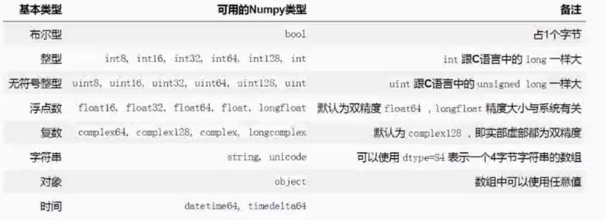

## 类型转换

```python
a = np.array([1.5,-3],dtype=float)
a
```

```
array([ 1.5, -3. ])
```

#### asarray函数

```python
a = np.array([1,2,3])
np.asarray(a,dtype=float)  #对数组进行转换
```

```
array([1., 2., 3.])
```

#### astype方法

```python
a = np.array([1,2,3])
a.astype(float)  #对数组进行转换
```

```
array([1., 2., 3.])
```

```python
a  #astype方法后，a数组依然是整型，没有改变
```

```
array([1, 2, 3])
```

```python
a = np.array([1,2,3])
b = a.astype(float)  #对数组进行转换
b
```

```
array([1., 2., 3.])
```

```python
b[0]=0.5
b
```

```
array([0.5, 2. , 3. ])
```

```python
a  #astype会产生一个新的数组，不对a进行改变
```

```
array([1, 2, 3])
```

# 3数组操作

### 以豆瓣十部高分电影为例

```python
import numpy as np
```

```python
##电影名称
mv_name=['肖申克的救赎','控方证人','美丽人生','阿甘正传','霸王别姬','泰坦尼克号','辛德勒名单','这个杀手不太冷','疯狂动物城','海豚湾']
```

```python
##评分人数
mv_num = np.array([692795,42995,327855,580897,478523,157047,306904,662552,284652,159302])
```

```python
##评分
mv_score = np.array([9.6,9.5,9.5,9.4,9.4,9.4,9.4,9.3,9.3,9.3])
```

```python
##电影时长（分钟）
mv_length = np.array([142,116,116,142,171,194,195,133,109,92])
```

## 数组排序

### sort函数

```python
np.sort(mv_num)
```

```
array([ 42995, 157047, 159302, 284652, 306904, 327855, 478523, 580897,
       662552, 692795])
```

```python
mv_num
```

```
array([692795,  42995, 327855, 580897, 478523, 157047, 306904, 662552,
       284652, 159302])
```

### argsort函数

**argsort返回从小到大的排列在数组中的索引位置**

```python
order = np.argsort(mv_num)
order
```

```
array([1, 5, 9, 8, 6, 2, 4, 3, 7, 0], dtype=int64)
```

```python
mv_name[order[0]]#评分人数最少的电影名
```

```
'控方证人'
```

```python
mv_name[order[-1]]#评分人数最多的电影名
```

```
'肖申克的救赎'
```

### 求和

```python
np.sum(mv_num)
```

```
3693522
```

```python
mv_num.sum()
```

```
3693522
```

### 最大值

```python
np.max(mv_length)
```

```
195
```

```python
mv_length.max()
```

```
195
```

### 最小值

```python
np.min(mv_score)
```

```
9.3
```

```python
mv_score.min()
```

```
9.3
```

### 均值

```python
np.mean(mv_length)
```

```
141.0
```

```python
mv_length.mean()
```

```
141.0
```

### 标准差

```python
np.std(mv_length)
```

```
33.713498780162226
```

```python
mv_length.std()
```

```
33.713498780162226
```

```python
np.cov(mv_score,mv_length)
```

```
array([[9.88888889e-03, 4.55555556e-01],
       [4.55555556e-01, 1.26288889e+03]])
```

## 多维数组操作

### 数组形状

```python
a = np.arange(6)
a
```

```
array([0, 1, 2, 3, 4, 5])
```

**将a数组转变成2行3列的数组：**

```python
a.shape=2,3
a
```

```
array([[0, 1, 2],
       [3, 4, 5]])
```

```python
a.shape
```

```
(2, 3)
```

**与之对应的方法是reshape，但它不会修改原来数组的值，而是返回一个新的数组**

```python
a=np.arange(6)
a
```

```
array([0, 1, 2, 3, 4, 5])
```

```python
a.reshape(2,3)
```

```
array([[0, 1, 2],
       [3, 4, 5]])
```

```python
a
```

```
array([0, 1, 2, 3, 4, 5])
```

```python
b = a.reshape(2,3)
b
```

```
array([[0, 1, 2],
       [3, 4, 5]])
```

### 转置

```python
a = a.reshape(2,3)
a
```

```
array([[0, 1, 2],
       [3, 4, 5]])
```

```python
a.T
```

```
array([[0, 3],
       [1, 4],
       [2, 5]])
```

```python
a.transpose()
```

```
array([[0, 3],
       [1, 4],
       [2, 5]])
```

```python
a
```

```
array([[0, 1, 2],
       [3, 4, 5]])
```

## 数组连接

**有时需要将不同的数组按照一定的顺序连接起来：**

**concatenate((a0,a1,...,aN),axis=0) axis代表拼接方向，默认是0，即按列拼接，若果为1，就是按行拼接**

### 注意：这些数组要用（）包括到一个元祖中去。

### 除了给定的轴外，这些数组其他轴的长度必须是一样的

```python
x = np.array([[0,1,2],[10,11,12]])
y = np.array([[50,51,52],[60,61,62]])
print(x.shape)
print(y.shape)
```

```
(2, 3)
(2, 3)
```

### 默认沿着第一维进行连接

```python
z = np.concatenate((x,y))
z
```

```
array([[ 0,  1,  2],
       [10, 11, 12],
       [50, 51, 52],
       [60, 61, 62]])
```

### 沿着第二维进行连接

```python
z = np.concatenate((x,y),axis=1)
z
```

```
array([[ 0,  1,  2, 50, 51, 52],
       [10, 11, 12, 60, 61, 62]])
```

#### 注意到这里x和y的形状是一样的，还可以将他们连接成三维的数组，但是concatenate不能够提供这样的功能，不过可以这样：

```python
z = np.array((x,y))
z
```

```
array([[[ 0,  1,  2],
        [10, 11, 12]],

       [[50, 51, 52],
        [60, 61, 62]]])
```

### 事实上，Numpy提供了分别对应这三种情况的函数：

- vstack
- hstack
- dstack

```python
np.vstack((x,y)) ## 垂直堆叠
```

```
array([[ 0,  1,  2],
       [10, 11, 12],
       [50, 51, 52],
       [60, 61, 62]])
```

```python
np.hstack((x,y))  ## 横向堆叠
```

```
array([[ 0,  1,  2, 50, 51, 52],
       [10, 11, 12, 60, 61, 62]])
```

```python
np.dstack((x,y))  ##三维堆叠
```

```
array([[[ 0, 50],
        [ 1, 51],
        [ 2, 52]],

       [[10, 60],
        [11, 61],
        [12, 62]]])
```

# numpy内置函数

```python
a = np.array([-1,2,3,-2])
a
```

```
array([-1,  2,  3, -2])
```

```python
np.abs(a)
```

```
array([1, 2, 3, 2])
```

```python
np.exp(a)
```

```
array([ 0.36787944,  7.3890561 , 20.08553692,  0.13533528])
```

```python
np.median(a)  #求中值
```

```
0.5
```

```python
np.cumsum(a) #累积和 -1 -1+2=1 -1+2+3=4  -1+2+3-2=2
```

```
array([-1,  1,  4,  2], dtype=int32)
```